# Assignment 04

Glib Dolotov

February 21, 2018

```r
library(tidyverse)
```

## 10.5 – Exercises

### 1.

How can you tell if an object is a tibble? (Hint: try printing `mtcars`, which is a regular data frame).

When printing, a tibble is labeled “A tibble” whereas a table doesn’t have a similar header:

```r
head(as.tibble(mtcars))
```

```
## # A tibble: 6 x 11
##     mpg   cyl  disp    hp  drat    wt  qsec    vs    am  gear  carb
##   <dbl> <dbl> <dbl> <dbl> <dbl> <dbl> <dbl> <dbl> <dbl> <dbl> <dbl>
## 1  21.0  6.00   160 110    3.90  2.62  16.5  0     1.00  4.00  4.00
## 2  21.0  6.00   160 110    3.90  2.88  17.0  0     1.00  4.00  4.00
## 3  22.8  4.00   108  93.0  3.85  2.32  18.6  1.00  1.00  4.00  1.00
## 4  21.4  6.00   258 110    3.08  3.22  19.4  1.00  0     3.00  1.00
## 5  18.7  8.00   360 175    3.15  3.44  17.0  0     0     3.00  2.00
## 6  18.1  6.00   225 105    2.76  3.46  20.2  1.00  0     3.00  1.00
```

```r
head(mtcars)
```

```
##                    mpg cyl disp  hp drat    wt  qsec vs am gear carb
## Mazda RX4         21.0   6  160 110 3.90 2.620 16.46  0  1    4    4
## Mazda RX4 Wag     21.0   6  160 110 3.90 2.875 17.02  0  1    4    4
## Datsun 710        22.8   4  108  93 3.85 2.320 18.61  1  1    4    1
## Hornet 4 Drive    21.4   6  258 110 3.08 3.215 19.44  1  0    3    1
## Hornet Sportabout 18.7   8  360 175 3.15 3.440 17.02  0  0    3    2
## Valiant           18.1   6  225 105 2.76 3.460 20.22  1  0    3    1
```

### 2.

Compare and contrast the following operations on a `data.frame` and equivalent tibble. What is different? Why might the default data frame behaviours cause you frustration?

```r
df <- data.frame(abc = 1, xyz = "a")
dt <- as.tibble(df)

df
```

```
##   abc xyz
## 1   1   a
```

```r
attributes(df)
```

```
## $names
## [1] "abc" "xyz"
##
## $row.names
## [1] 1
##
## $class
## [1] "data.frame"
```

```r
dt
```

```
## # A tibble: 1 x 2
##     abc xyz
##   <dbl> <fct>
## 1  1.00 a
```

```r
attributes(dt)
```

```
## $names
## [1] "abc" "xyz"
##
## $row.names
## [1] 1
##
## $class
## [1] "tbl_df"     "tbl"        "data.frame"
```

```r
df$x
```

```
## [1] a
## Levels: a
```

```r
dt$x
```

[output not shown]

```r
# Specifying a single "box" within a data-frame yields the actual object within
# the data-frame.
df[, "xyz"]
```

```
## [1] a
## Levels: a
```

```r
attributes(df[,"xyz"])
```

```
## $levels
## [1] "a"
##
## $class
## [1] "factor"
```

```r
# However selecting a subset of a data-frame that has multiple "boxes" yields a
# data-frame
df[, c("abc", "xyz")]
```

```
##   abc xyz
## 1   1   a
```

```r
attributes(df[, c("abc","xyz")])
```

```
## $names
## [1] "abc" "xyz"
##
## $class
## [1] "data.frame"
##
## $row.names
## [1] 1
```

```r
# Meanwhile any subset of a tibble, no matter how small, is also a tibble.
dt[, "xyz"]
```

```
## # A tibble: 1 x 1
##   xyz
##   <fct>
## 1 a
```

```r
attributes(dt[,"xyz"])
```

```
## $names
## [1] "xyz"
##
## $row.names
## [1] 1
##
## $class
## [1] "tbl_df"     "tbl"        "data.frame"
```

```r
dt[, c("abc", "xyz")]
```

```
## # A tibble: 1 x 2
##     abc xyz
##   <dbl> <fct>
## 1  1.00 a
```

```r
attributes(dt[, c("abc","xyz")])
```

```
## $names
## [1] "abc" "xyz"
##
## $row.names
## [1] 1
##
## $class
## [1] "tbl_df"     "tbl"        "data.frame"
```

### 3.

If you have the name of a variable stored in an object, e.g. `var <- "mpg"`, how can you extract the reference variable from a tibble?

```r
var <- "mpg"
ct <- as.tibble(mtcars)
ct[var]
```

```
## # A tibble: 32 x 1
##      mpg
##    <dbl>
##  1  21.0
##  2  21.0
##  3  22.8
##  4  21.4
##  5  18.7
##  6  18.1
##  7  14.3
##  8  24.4
##  9  22.8
## 10  19.2
## # ... with 22 more rows
```

```r
ct[[var]]
```

```
##  [1] 21.0 21.0 22.8 21.4 18.7 18.1 14.3 24.4 22.8 19.2 17.8 16.4 17.3 15.2
## [15] 10.4 10.4 14.7 32.4 30.4 33.9 21.5 15.5 15.2 13.3 19.2 27.3 26.0 30.4
## [29] 15.8 19.7 15.0 21.4
```

### 4.

```r
annoying <- tibble(
  `1` = 1:10,
  `2` = `1` * 2 + rnorm(length(`1`))
)
```

Practice referring to non-syntactic names in the data frame by:

1. Extracting the variable called `1`.

```r
annoying[["1"]]
```

```
##  [1]  1  2  3  4  5  6  7  8  9 10
```

```r
annoying$`1`
```

```
##  [1]  1  2  3  4  5  6  7  8  9 10
```

2. Plotting a scatterplot of `1` vs `2`.

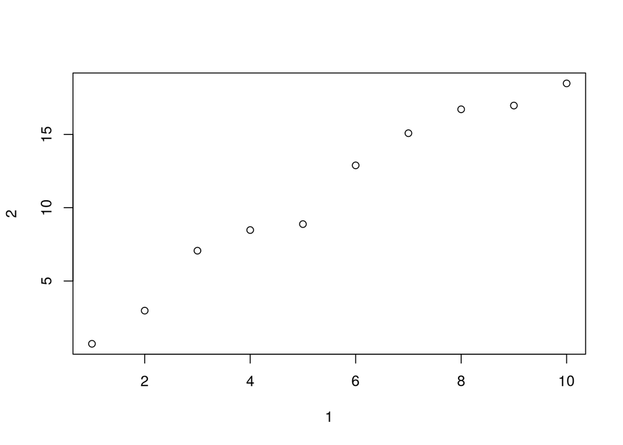

```r
plot(annoying)
```

3. Creating a new column called `3` which is `2` divided by `1`.

```r
less_annoying <- bind_cols(annoying,
                           tibble(`3` = annoying$`2`/annoying$`1`))
less_annoying
```

```
## # A tibble: 10 x 3
##      `1`    `2`   `3`
##    <int>  <dbl> <dbl>
##  1     1  0.717 0.717
##  2     2  2.98  1.49
##  3     3  7.07  2.36
##  4     4  8.48  2.12
##  5     5  8.88  1.78
##  6     6 12.9   2.15
##  7     7 15.1   2.15
##  8     8 16.7   2.09
##  9     9 17.0   1.89
## 10    10 18.5   1.85
```

4. Renaming the columns to `one`, `two` and `three`.

```r
attributes(less_annoying)
```

```
## $row.names
##  [1]  1  2  3  4  5  6  7  8  9 10
##
## $class
## [1] "tbl_df"     "tbl"        "data.frame"
##
## $names
## [1] "1" "2" "3"
```

```r
re_name <- function(tib, old, nu){
  attr(tib,'names')[match(old, attr(tib,'names'))] = nu
}
# For some reason the above function doesn't work, but the below lines, which
# are identical to the function with variable names manually plugged in, do
# work.
attr(less_annoying,'names')[match(1, attr(less_annoying,'names'))] <- 'one'
attr(less_annoying,'names')[match(2, attr(less_annoying,'names'))] <- 'two'
attr(less_annoying,'names')[match(3, attr(less_annoying,'names'))] <- 'three'
less_annoying
```

```
## # A tibble: 10 x 3
##      one    two three
##    <int>  <dbl> <dbl>
##  1     1  0.717 0.717
##  2     2  2.98  1.49
##  3     3  7.07  2.36
##  4     4  8.48  2.12
##  5     5  8.88  1.78
##  6     6 12.9   2.15
##  7     7 15.1   2.15
##  8     8 16.7   2.09
##  9     9 17.0   1.89
## 10    10 18.5   1.85
```

### 5.

What does `tibble::enframe()` do? When might you use it?

As per `?enframe`: “`enframe()` converts named vectors or lists to two-column data frames. For unnamed vectors, the natural sequence is used as name column.” It would be useful when we need to take a long vector or list and convert it into a tibble.

### 6.

What option controls how many additional column names are printed at the footer of a tibble?

`getOption("tibble.max_extra_cols")`

## 12.6.1 – Exercises

### 1.

In this case study I set `na.rm = TRUE` just to make it easier to check that we had the correct values. Is this reasonable? Think about how missing values are represented in this dataset. Are there implicit missing values? What’s the difference between an `NA` and zero?

There are no implicit missing values. Any operations on `NA` yield `NA` whereas operations on zero yield various results.

### 2.

What happens if you neglect the `` mutate()`` step? ( ``mutate(key = stringr::str_replace(key, “newrel”, “new_rel”))```)

You fail to prepare a part of the data for the `separate` step which assumes that there will be “_" between parts of the code (key) that we describe as “new”, “type”, and “sexage”.

```r
test <- tibble(key = c(1:2), value = c("newrel_f5564", "new_rel_f5565"))
test %>%
  separate(value, c("new", "type", "sexage"), sep = "_")
```

```
## # A tibble: 2 x 4
##     key new    type  sexage
##   <int> <chr>  <chr> <chr>
## 1     1 newrel f5564 <NA>
## 2     2 new    rel   f5565
```

### 3.

I claimed that `iso2` and `iso3` were redundant with country. Confirm this claim.

```r
# Create a reference table of which "country" values should match to which
# "iso2" and "iso3" values.
comp = data.frame(unique(who$country), unique(who$iso2), unique(who$iso3))

# The three calls below evaluate to "1" if for every row in "who", the
# "country", "iso2", and "iso3" values match correctly.
# i.e. makes sure that "United States of America" always matches to "US" which
#      always matches to "USA".
prod(match(who$country,comp[,1]) == match(who$iso2,comp[,2]))
```

```
## [1] 1
```

```r
prod(match(who$country,comp[,1]) == match(who$iso3,comp[,3]))
```

```
## [1] 1
```

```r
prod(match(who$iso3,comp[,3]) == match(who$iso2,comp[,2]))
```

```
## [1] 1
```

### 4.

For each country, year, and sex compute the total number of cases of TB. Make an informative visualisation of the data.

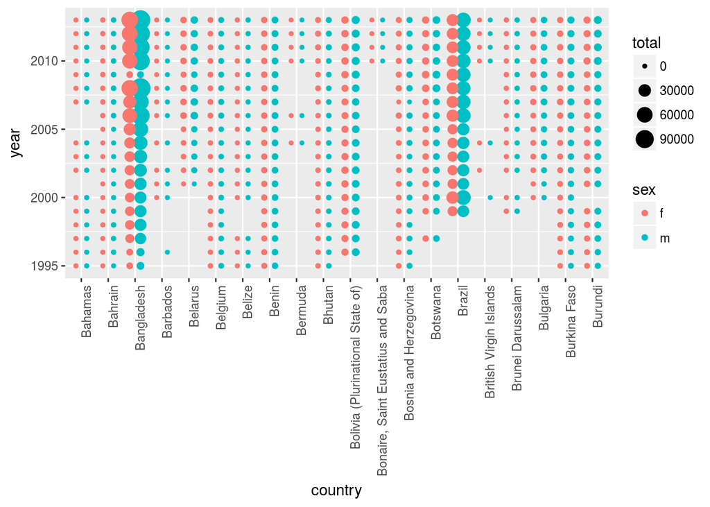

```r
who2 <- who %>%
  gather(code, value, new_sp_m014:newrel_f65, na.rm = TRUE) %>%
  mutate(code = stringr::str_replace(code, "newrel", "new_rel")) %>%
  separate(code, c("new", "var", "sexage")) %>%
  select(-new, -iso2, -iso3) %>%
  separate(sexage, c("sex", "age"), sep = 1)

who3 <- who2 %>% group_by(country, sex, year) %>% summarize(total = sum(value))

plotwho <- function(excl_low, incl_hi){
  ggplot(filter(who3, country < incl_hi, country > excl_low),
         aes(country,
             year,
             size = total,
             color = sex,
             group = sex)
         ) +
  theme(axis.text.x = element_text(angle = 90, hjust = 1)) +
  geom_point(position = position_dodge(width = 0.8))
}

plotwho("B","C")
```

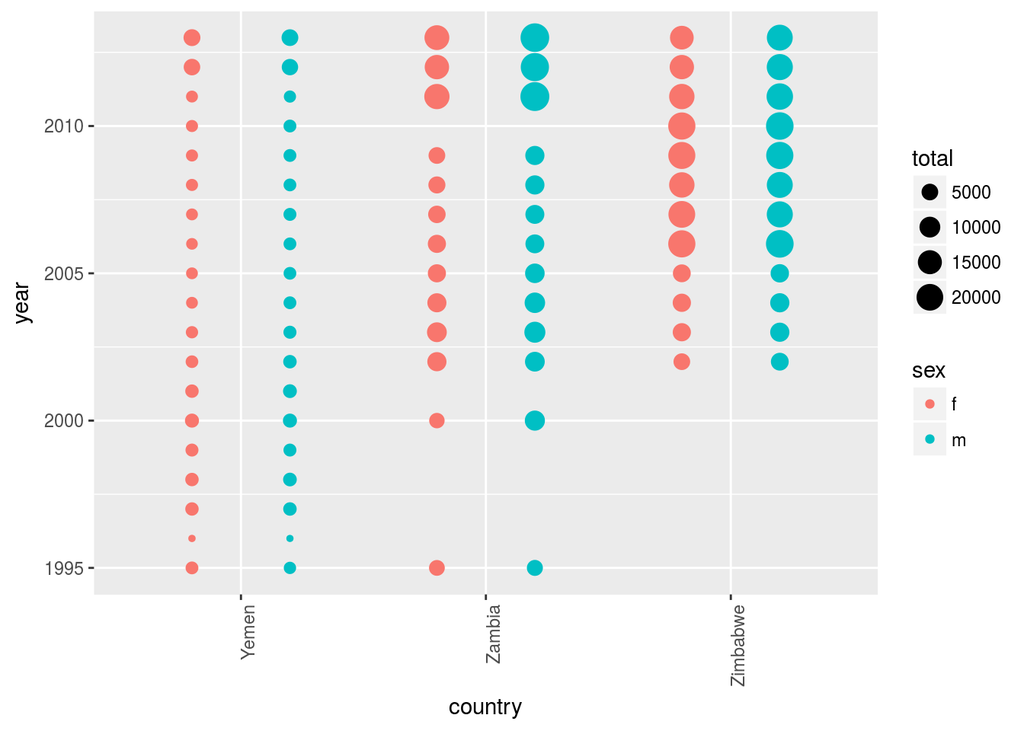

```r
plotwho("X","ZZ")
```